# deep_learning_eda

Sreeram Peela

2024-05-08

## R Markdown

The file contains exploratory data analysis (EDA) of “Churn modelling” dataset. The dependent feature is “Exited”, while all the other features are considered features. Prior to usig the dataset for classification problems, I would like to perform a biref statistical analysis.

The goal is to identify features that are significantly different in the groups: exited (encoded as 1) and not-exited (encoded as 0). For the purpose of EDA, the original datafile is used, and not the cleaned one (with scaled data).

```r
## load required packages
library(ggplot2)
library(dplyr)
library(reshape2)
```

Loading the dataset

```r
df <- read.csv("Churn_Modelling.csv", stringsAsFactors = T)
```

Performing some feature recoding: Some of the binary/categorical features are encoded as 0 and 1.

```r
#removing customer id and surname features as they are not relevant
df <- select(df, -c(1,2))
summary(df)
```

```
##   CreditScore      Geography       Gender          Age            Tenure
##  Min.   :350.0   France :5014   Female:4543   Min.   :18.00   Min.   : 0.000
##  1st Qu.:584.0   Germany:2509   Male  :5457   1st Qu.:32.00   1st Qu.: 3.000
##  Median :652.0   Spain  :2477                 Median :37.00   Median : 5.000
##  Mean   :650.5                                Mean   :38.92   Mean   : 5.013
##  3rd Qu.:718.0                                3rd Qu.:44.00   3rd Qu.: 7.000
##  Max.   :850.0                                Max.   :92.00   Max.   :10.000
##     Balance       NumOfProducts    HasCrCard      IsActiveMember
##  Min.   :     0   Min.   :1.00   Min.   :0.0000   Min.   :0.0000
##  1st Qu.:     0   1st Qu.:1.00   1st Qu.:0.0000   1st Qu.:0.0000
##  Median : 97199   Median :1.00   Median :1.0000   Median :1.0000
##  Mean   : 76486   Mean   :1.53   Mean   :0.7055   Mean   :0.5151
##  3rd Qu.:127644   3rd Qu.:2.00   3rd Qu.:1.0000   3rd Qu.:1.0000
##  Max.   :250898   Max.   :4.00   Max.   :1.0000   Max.   :1.0000
##  EstimatedSalary         Exited
##  Min.   :    11.58   Min.   :0.0000
##  1st Qu.: 51002.11   1st Qu.:0.0000
##  Median :100193.91   Median :0.0000
##  Mean   :100090.24   Mean   :0.2037
##  3rd Qu.:149388.25   3rd Qu.:0.0000
##  Max.   :199992.48   Max.   :1.0000
```

```r
#recoding as factors
df$NumOfProducts <- as.factor(df$NumOfProducts)
df$HasCrCard <- as.factor(df$HasCrCard)
df$IsActiveMember <- as.factor(df$IsActiveMember)
summary(df)
```

```
##   CreditScore      Geography       Gender          Age            Tenure
##  Min.   :350.0   France :5014   Female:4543   Min.   :18.00   Min.   : 0.000
##  1st Qu.:584.0   Germany:2509   Male  :5457   1st Qu.:32.00   1st Qu.: 3.000
##  Median :652.0   Spain  :2477                 Median :37.00   Median : 5.000
##  Mean   :650.5                                Mean   :38.92   Mean   : 5.013
##  3rd Qu.:718.0                                3rd Qu.:44.00   3rd Qu.: 7.000
##  Max.   :850.0                                Max.   :92.00   Max.   :10.000
##     Balance       NumOfProducts HasCrCard IsActiveMember EstimatedSalary
##  Min.   :     0   1:5084        0:2945    0:4849         Min.   :    11.58
##  1st Qu.:     0   2:4590        1:7055    1:5151         1st Qu.: 51002.11
##  Median : 97199   3: 266                                 Median :100193.91
##  Mean   : 76486   4:  60                                 Mean   :100090.24
##  3rd Qu.:127644                                          3rd Qu.:149388.25
##  Max.   :250898                                          Max.   :199992.48
##      Exited
##  Min.   :0.0000
##  1st Qu.:0.0000
##  Median :0.0000
##  Mean   :0.2037
##  3rd Qu.:0.0000
##  Max.   :1.0000
```

```r
cat_results <- list(pvalues = c(), odds_ratio = c(), feature_names = c())
#using fisher test or chisquare test for categorical associations
cat_features <- c(2,3,7,8,9)
for (i in cat_features) {
  unique_cats <- unique(df[ , i])
  cross_tab <- table(df[ , i], df[ , "Exited"])
  colName <- colnames(df)[i]
  cat_results$feature_names <- c(cat_results$feature_names, colName )
  #cat_results$cont_tables <- c(cat_results$cont_tables, matrix(cross_tab,
                              #nrow=nrow(cross_tab), ncol = ncol(cross_tab)))
  if (length(unique_cats) == 2) {
    # run Fisher test
    fisher_test <- fisher.test(cross_tab, conf.int = TRUE, conf.level = 0.95)
    cat_results$pvalues <- c(cat_results$pvalues, fisher_test$p.value)
    cat_results$odds_ratio <- c(cat_results$odds_ratio, fisher_test$estimate)
    #cat_results$odd_ratio_CI <- c(cat_results$odd_ratio_CI, fisher_test$conf.int)

  } else {
    # run chisquare test
    # no odds ratio for chi-square test
    chi_test <- chisq.test(cross_tab)
    cat_results$pvalues <- c(cat_results$pvalues, chi_test$p.value)
    cat_results$odds_ratio <- c(cat_results$odds_ratio, NA)
    #cat_results$odd_ratio_CI <- c(cat_results$odd_ratio_CI, c(NA, NA))

  }
}
print(cat_results)
```

```
## $pvalues
## [1] 3.830318e-66 2.239739e-26 0.000000e+00 4.789162e-01 2.294161e-55
##
## $odds_ratio
##            odds ratio            odds ratio odds ratio
##         NA  0.5887181         NA  0.9620566  0.4534610
##
## $feature_names
## [1] "Geography"      "Gender"         "NumOfProducts"  "HasCrCard"
## [5] "IsActiveMember"
```

```r
cat_results_df <- data.frame("feature" = cat_results$feature_names,
                             "pval" = cat_results$pvalues,
                             "odds" = round(cat_results$odds_ratio, 3))
sign_features <- cat_results_df[cat_results_df$pval<0.05, "feature"]
print(sign_features)
```

```
## [1] "Geography"      "Gender"         "NumOfProducts"  "IsActiveMember"
```

From the above observation, has card doesn’t seem to be associated with exited status.

Performing EDA using continuous variables

```r
cont_features <- c(1,4,5,6,10)
shapiro_results <- list("pvalue" = c(), "feature" = c())
#checking normality assumptions
# using Anderson-Darling normality test as n_samples > 5000
library(nortest)
for (i in cont_features) {
  pval <- ad.test(df[ , i])$p.value
  colname <- colnames(df)[i]
  shapiro_results$pvalue <- c(shapiro_results$pvalue, pval)
  shapiro_results$feature <- c(shapiro_results$feature, colname)
}

print(shapiro_results)
```

```
## $pvalue
## [1] 1.855676e-13 3.700000e-24 3.700000e-24 3.700000e-24 3.700000e-24
##
## $feature
## [1] "CreditScore"     "Age"             "Tenure"          "Balance"
## [5] "EstimatedSalary"
```

As seen from above, none of the variables are normally distributed. Using correlation to detect collinear variables

```r
df_cont <- select(df, cont_features)
cor_matrix <- cor(df_cont)
print(cor_matrix)
```

```
##                   CreditScore          Age        Tenure      Balance
## CreditScore      1.0000000000 -0.003964906  0.0008419418  0.006268382
## Age             -0.0039649055  1.000000000 -0.0099968256  0.028308368
## Tenure           0.0008419418 -0.009996826  1.0000000000 -0.012253926
## Balance          0.0062683816  0.028308368 -0.0122539262  1.000000000
## EstimatedSalary -0.0013842929 -0.007201042  0.0077838255  0.012797496
##                 EstimatedSalary
## CreditScore        -0.001384293
## Age                -0.007201042
## Tenure              0.007783825
## Balance             0.012797496
## EstimatedSalary     1.000000000
```

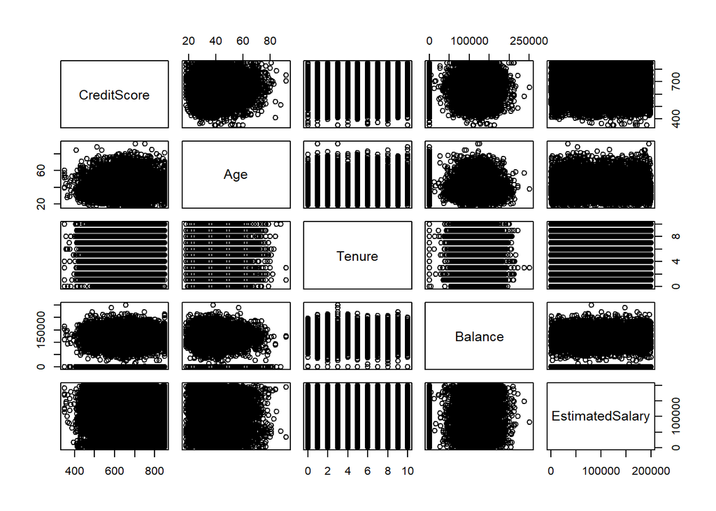

```r
pairs(df_cont)
```

```r
df_cont$Exited <- df$Exited
levels(df_cont$Exited)[levels(df_cont$Exited) == "1"] <- "YES"
levels(df_cont$Exited)[levels(df_cont$Exited) == "0"] <- "NO"
```

Using Mann-Whitney test for two groups comparison As wilcox.test is the function used

```r
pvals = c()
var_names = c()
for (i in 1:4) {
  varname = colnames(df_cont)[i]
  ind_var <- df_cont[ , i]
  stat_test <- wilcox.test(ind_var~df_cont$Exited)
  var_names <- c(var_names, varname)
  pvals <- c(pvals, stat_test$p.value)

}

cont_res <- list("pvals"=pvals, "feature" = var_names)
```

Generating box plots

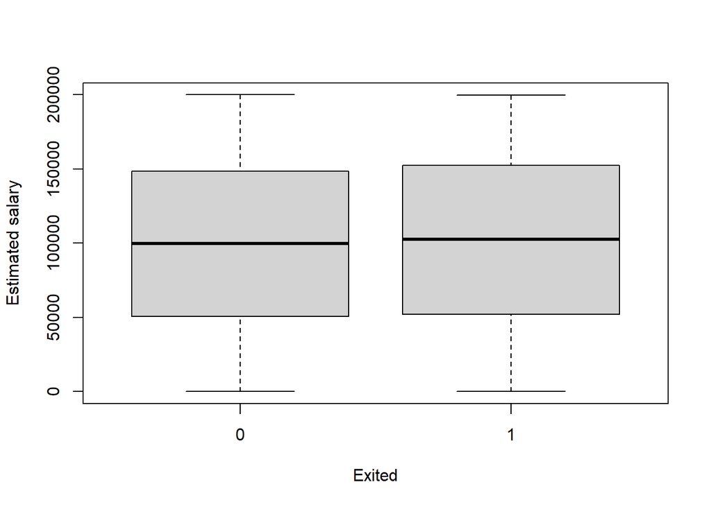

```r
# drawing boxplots
cont_vars <- colnames(df_cont)[1:4]
library(ggpubr)
library(gridGraphics)
# we have four continuous features
# creating a 2x2 plot
#par(mfrow=c(2,2))
plot1 <- boxplot(df$EstimatedSalary ~ df$Exited, xlab = "Exited",
                 ylab = "Estimated salary")
```

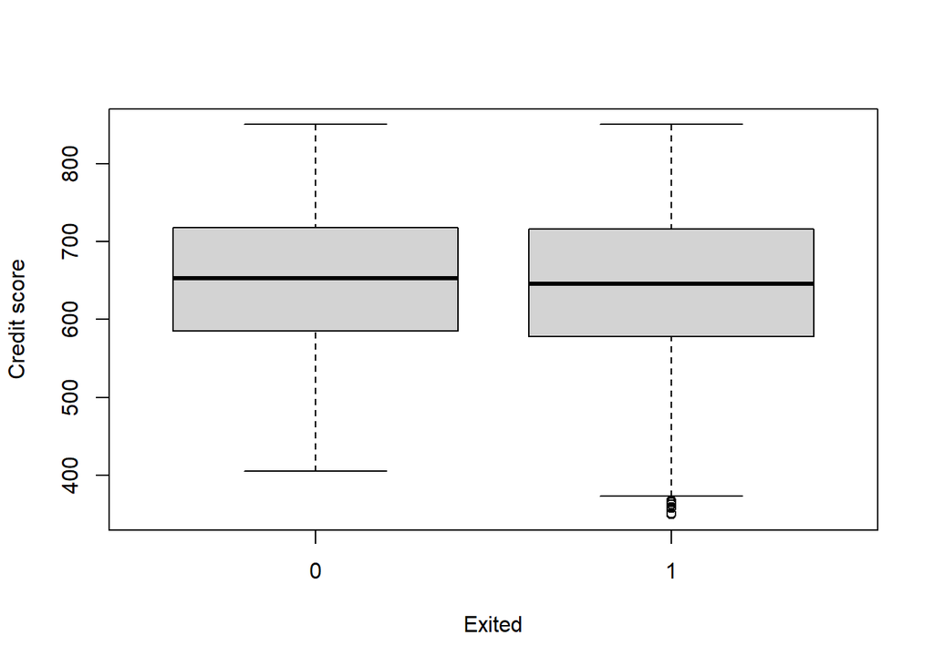

```r
plot2 <- boxplot(df$CreditScore ~ df$Exited, xlab = "Exited",
                 ylab = "Credit score")
```

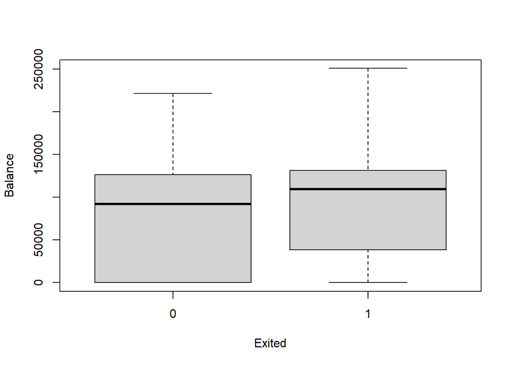

```r
plot3 <- boxplot(df$Balance ~ df$Exited, xlab = "Exited",
                 ylab = "Balance")
```

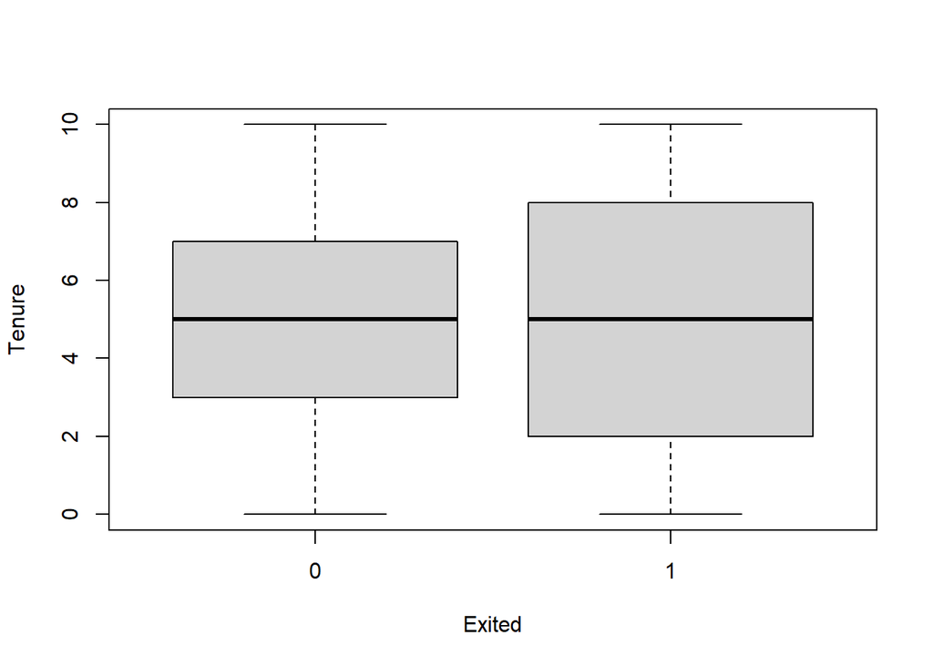

```r
plot4 <- boxplot(df$Tenure ~ df$Exited, xlab = "Exited",
                 ylab = "Tenure")
```

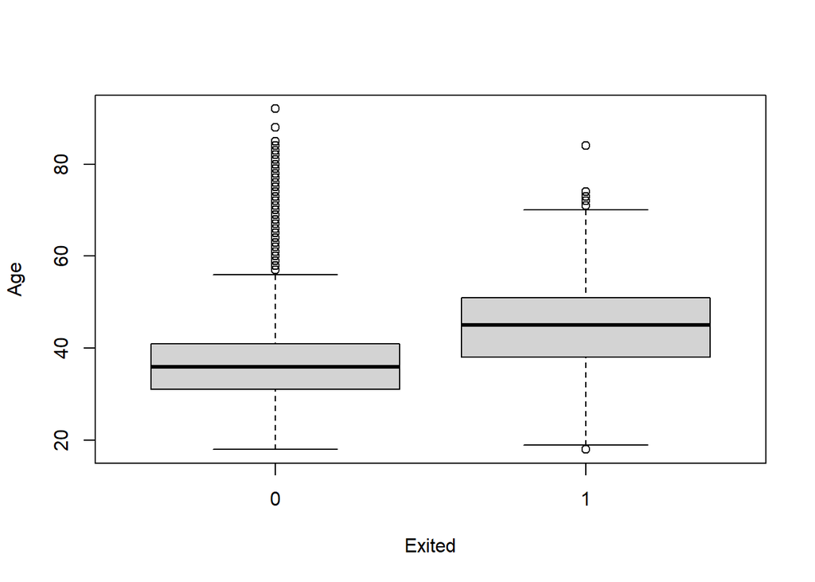

```r
plot5 <- boxplot(df$Age ~ df$Exited, xlab = "Exited",
                 ylab = "Age")
```

```r
pvals = c()
var_names = c()
for (i in 1:4) {
  varname = colnames(df_cont)[i]
  ind_var <- df_cont[ , i]
  stat_test <- wilcox.test(ind_var~df_cont$Exited)
  var_names <- c(var_names, varname)
  pvals <- c(pvals, stat_test$p.value)

}

cont_res <- list("pvals"=pvals, "feature" = var_names)
```

```r
cont_res_df <- data.frame("feature" = cont_res$feature, "pval" = cont_res$pvals)
cont_res_df[cont_res_df$pval < 0.05, "feature"]
```

```
## [1] "CreditScore" "Age"         "Balance"
```

Interpretation: As seen from the above results, only these three variables were significantly different among those exited and non-exited.